# Предсказание количества поездок желтого такси в Нью-Йорке

Данный проект это финальная часть из 6 курсовой специализации от Яндекса/МФТИ на Coursera

https://www.coursera.org/learn/data-analysis-project/home/welcome

## Описание

В данном проекте ставилась задача предсказания количества поездок желтого такси в отдельных регионах Нью-Йорка

Сырые данные для проекта берутся с сайта TLC: http://www.nyc.gov/html/tlc/html/about/trip_record_data.shtml

и представляют собой отдельные записи о каждой поездке:

- координаты старта,
- координаты финиша,
- длительность,
- цена,
- и многое другое

Для предсказания данные агрегировались в количество в час по 2500 одинаковых ячеек в городе, из которых были выбраны для предсказания те 102, в которых с среднем в мае было больше 5 поездок в час

### Запуск ноутбука

```python
%run project_maintance.py
(display_data_map,
     show_hist_data,
     feat,
     display_pred_map,
     show_pred_data,
     show_clusters,
     show_clusters_reps,
     show_map_clusters,
     show_predn_data) = run_notebook()
```

### Обработанные данные на карте

Выбирая дату и час можно посмотреть на карте количество поездок такси

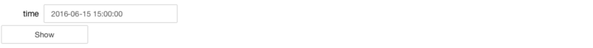

[interactive chart not shown]

```python
display_data_map()
```

Выбирая регионы (можно выбрать несколько) и временной промежуток можно посмотреть на ряды данных

Если выбрать длинный промежуток, то желательно взять resample (здесь аггрегация - сумма) днем или неделей, чтобы график остался читаемым

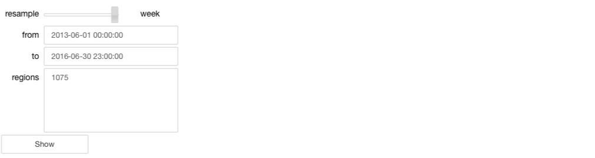

[interactive chart not shown]

```python
show_hist_data()
```

# Предсказание количества поездок

## Без исторических признаков

Здесь количество поездок было предсказано без использования каких-либо исторических данных

Каждый регион предсказывался отдельной линейной регрессией

Были использованы такие признаки как:

- полиномиальные признаки тренда
- гармонические признаки недельной и годовой сезонностей
- признак номера часа суток
- признаки праздника
- признаки номера недели месяца
- множество произведений признаков, особенно с признаком номера часа суток

Как значения, так и признаки сначала были нормализованы

##### Таблица признаков

```python
feat.head(2)
```

| datetime | x0 | x1 | x2 | week_sin1 | week_cos1 | week_sin2 | week_cos2 | week_sin3 | week_cos3 | week_sin4 | ... | hour23_x_month3 | hour23_x_month4 | hour23_x_month5 | hour23_x_month6 | hour23_x_month7 | hour23_x_month8 | hour23_x_month9 | hour23_x_month10 | hour23_x_month11 | hour23_x_month12 |
| --- | --- | --- | --- | --- | --- | --- | --- | --- | --- | --- | --- | --- | --- | --- | --- | --- | --- | --- | --- | --- | --- |
| 2012-01-01 00:00:00 | 1.0 | 0.000000 | 0.000000e+00 | 0.000000 | 1.000000 | 0.000000 | 1.000000 | 0.000000 | 1.000000 | 0.000000 | ... | 0.0 | 0.0 | 0.0 | 0.0 | 0.0 | 0.0 | 0.0 | 0.0 | 0.0 | 0.0 |
| 2012-01-01 01:00:00 | 1.0 | 0.000025 | 6.431680e-10 | 0.037392 | 0.999301 | 0.074732 | 0.997204 | 0.111967 | 0.993712 | 0.149046 | ... | 0.0 | 0.0 | 0.0 | 0.0 | 0.0 | 0.0 | 0.0 | 0.0 | 0.0 | 0.0 |

2 rows × 659 columns

### Интерактивная карта

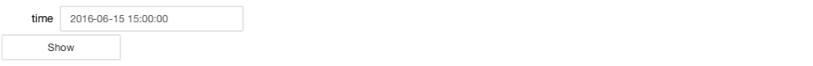

[interactive chart not shown]

```python
display_pred_map()
```

### Значения предсказаний

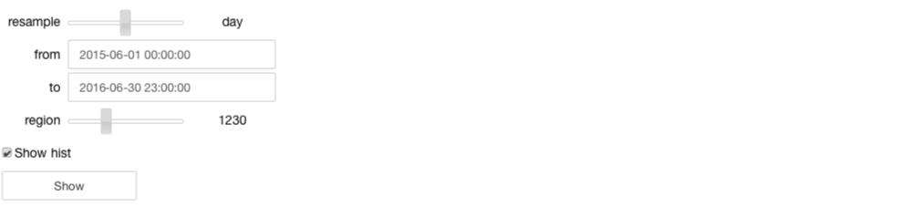

[interactive chart not shown]

```python
show_pred_data()
```

## С историческими признаками

Здесь предсказывались значения рядов на 1, 2, 3, 4, 5 и 6 часов вперед

Для каждого из 6 часов вперед и для каждого ряда обучалась отдельная линейная регрессия, так же с L2-регуляризацией

Для предсказания, помимо всех уже перечисленных выше признаков, использовались и исторические признаки:

- признаки значений ряда за предыдущие часы
- признаки значений текущего часа дня в предыдущие дни и недели
- максимальное и минимальное значения в некотором окне
- плавающие среднее и отклонение в некотором окне

Соответственно при обучении регрессии на 6 (5, 4, ...) часов вперед, ей недоступны любые признаки использующий исторические данные за предыдущие 6 (5, 4, ...) часов

#### Так же использовались исторические значения других рядов

Использование значений сразу всех других рядов приводило к переобучению, от которого помогала лишь очень сильная регуляризация, что портило качество модели

Поэтому типы рядов были кластеризованы в несколько кластеров, из которых брались характерные представители, и уже история этих представителей использовалась

### Визуализация MDS рядов кластеров

Особого разделения на кластеры не видно, причем методом t-SNE еще хуже, однако, чем больше кластеров, тем больше ряды внутри кластеров схожи

Кластеризовались нормализованные ряды, поэтому имели значения лишь формы рядов в кластерах

```python
show_clusters()
```

[interactive chart not shown]

##### Характерные представители каждого кластера

Видно существенное различие паттерна рядов

```python
show_clusters_reps()
```

[interactive chart not shown]

##### Распределение кластеров на карте

Кластеры географически близки, а аэропорты, например, в своем, отдельном, кластере

```python
show_map_clusters()
```

[interactive chart not shown]

### Значения предсказаний на n часов вперед

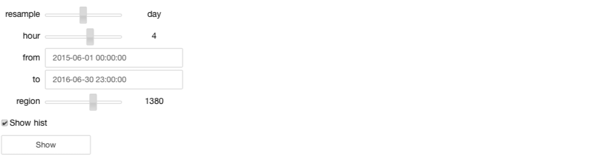

[interactive chart not shown]

```python
show_predn_data()
```

## Больше про обучение, сравнение методов и использованная метрика

Модели обучались на данных с 2012-05-31 23:00:00 по 2016-04-30 17:00:00

Кросс-Валидация на данных с 2016-04-30 23:00:00 по 2016-05-31 17:00:00

Тестирование на данных с 2016-05-31 23:00:00 по 2016-06-30 17:00:00

##### Метрика сравнения моделей на этапе Кросс-Валидации

$$ Q_{may} =\frac1{R * 739* 6} \sum\limits_{r=1}^{R} \sum_{T=2016.04.30 \ 23:00}^{2016.05.31 \ 17:00} \sum_{i=1}^6 \left| \hat{y}^r_{T|T+i} - y^r_{T+i} \right| $$

##### Метрика сравнения моделей на этапе тестирования

$$ Q_{june} =\frac1{R * 715* 6} \sum\limits_{r=1}^{R} \sum_{T=2016.05.31 \ 23:00}^{2016.06.30 \ 17:00} \sum_{i=1}^6 \left| \hat{y}^r_{T|T+i} - y^r_{T+i} \right| $$

#### Без исторических данных было получено наилучшее значение в 20.32

#### С историческими данными - 13.42

С другой стороны модель без исторических данных отвязана от истории и может предсказывать значения на любое время (в разумных пределах)

## Ссылка на submission в kaggle

https://inclass.kaggle.com/c/yellowtaxi/leaderboard?submissionId=4037937